# Egzaminas

Linas Šyvis

**Reikalingi užduotims paketai**

```r
library(car)
library(dynlm)
library(fpp)
```

# 1 užduotis

```r
skirst <- as.numeric(0)
for(i in -20:20)
skirst[i] <- dnorm(i, mean = 2, sd = 3)
```

**Sugeneruojame imtį, su N narių.** Apsirašome funkciją pagal pateiktą apibrėžimą.

```r
eksp <- function()
{
  x1 <- rnorm(n = 1, mean = 3, sd = 2)
  x2 <- rnorm(n = 1, mean = -1, sd = 3)
  return(c(x1, x2))
}
```

Simuliuojame eksperimentą N kartų.

```r
N <- 10000
sim <- as.numeric(0)
for(i in 1:N)
  sim[i] <- sum(eksp())
```

**Palyginame teorinį ir empirinį skirstinius.** Tankių grafikai

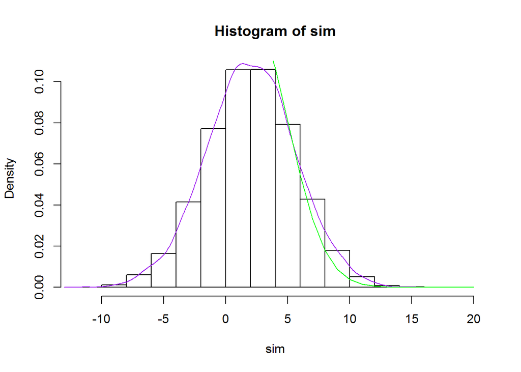

```r
hist(sim, probability = TRUE)
lines(density(sim, bw = 0.5), col = "purple")
lines(skirst, col = "green")
```

Skirstinio charakteristikos

```r
mean(sim)
```

```
## [1] 2.012621
```

```r
mean(2)
```

```
## [1] 2
```

```r
median(sim)
```

```
## [1] 2.031408
```

```r
median(skirst)
```

```
## [1] 0.002637972
```

```r
var(sim)
```

```
## [1] 12.90946
```

```r
var(5)
```

```
## [1] NA
```

4. Monte Carlo:

```r
tik <- mean(replicate(10000,((sum(eksp()))^2 - mean(sum(eksp())) - 2))>0)
tik
```

```
## [1] 0.6792
```

# 2 užduotis

**1.**

**Nuskaitome duomenis.**

```r
data1 <- read.csv2("data_b.csv", header = TRUE)
data1 <- data1[-c(416:422),]
```

**Apžvelgiame duomenis**

```r
head(data1)
```

```
##    islaidosVaisiams  butinosIslaidos          pajamos rajonoId
## 1  0.55264716607673  14.083383988741 27.1976217672389        2
## 2 0.352043570132186 13.3340536630728 9.23356048254358        1
## 3  0.41054439096652   5.444672968536 9.32350585248842        1
## 4 0.609335946811592 13.4877843946138 30.3525419571229        1
## 5 0.620213786386003 13.9682753211176 30.6464386758047        2
## 6 0.390109892744539 11.7340601203773  12.107559010339        3
##   atstumasIkiParduotuves
## 1       1464.66699771618
## 2       1610.16704945958
## 3       1553.04420636911
## 4       1391.91687372238
## 5       1335.35514006074
## 6       860.981545754901
```

```r
sum(data1 == "NAN")
```

```
## [1] 5
```

Matome, kad yra trūkstamų reikšmių, reikia jas pašalinti.

**Pašaliname trūkstamas reikšmes**

```r
data1[data1 == "NAN"] <- NA
data2 <- na.omit(data1)
data2$rajonoId <- factor(data2$rajonoId)#visiškai pašaliname NAN reikšmę iš factor kintamojo
attach(data2)
```

**Pakoreguojame duomenų tipus**

```r
str(data2)
```

```
## 'data.frame':    410 obs. of  5 variables:
##  $ islaidosVaisiams      : Factor w/ 421 levels "/   atstumasIkiParduotuves - atstumas iki prekybos centro",..: 270 118 162 321 330 145 33 219 184 117 ...
##  $ butinosIslaidos       : Factor w/ 416 levels "","10.0001111842212",..: 182 153 292 160 179 82 336 78 64 140 ...
##  $ pajamos               : Factor w/ 416 levels "","10.0319685967662",..: 169 401 402 212 216 36 320 130 382 2 ...
##  $ rajonoId              : Factor w/ 3 levels "1","2","3": 2 1 1 1 2 3 2 1 3 2 ...
##  $ atstumasIkiParduotuves: Factor w/ 416 levels "","1014.62131670009",..: 123 218 182 76 54 405 231 360 155 91 ...
##  - attr(*, "na.action")=Class 'omit'  Named int [1:5] 9 57 97 154 301
##   .. ..- attr(*, "names")= chr [1:5] "9" "57" "97" "154" ...
```

Matome, kad islaidosVaisiams, butinosIslaidos, pajamos ir atstumasIkiParduotuves kintamieji yra factor tipo, tai mums trukdo sukurti modelį, pakeiskime jų tipą į numeric [rajonoId paliksime, kaip žymimąjį kintamąjį].

```r
data2[, 1] = as.numeric(paste(data2[, 1]))
data2[, 2] = as.numeric(paste(data2[, 2]))
data2[, 3] = as.numeric(paste(data2[, 3]))
data2[, 5] = as.numeric(paste(data2[, 5]))
str(data2)
```

```
## 'data.frame':    410 obs. of  5 variables:
##  $ islaidosVaisiams      : num  0.553 0.352 0.411 0.609 0.62 ...
##  $ butinosIslaidos       : num  14.08 13.33 5.44 13.49 13.97 ...
##  $ pajamos               : num  27.2 9.23 9.32 30.35 30.65 ...
##  $ rajonoId              : Factor w/ 3 levels "1","2","3": 2 1 1 1 2 3 2 1 3 2 ...
##  $ atstumasIkiParduotuves: num  1465 1610 1553 1392 1335 ...
##  - attr(*, "na.action")=Class 'omit'  Named int [1:5] 9 57 97 154 301
##   .. ..- attr(*, "names")= chr [1:5] "9" "57" "97" "154" ...
```

**Ieškosime išskirčių.**

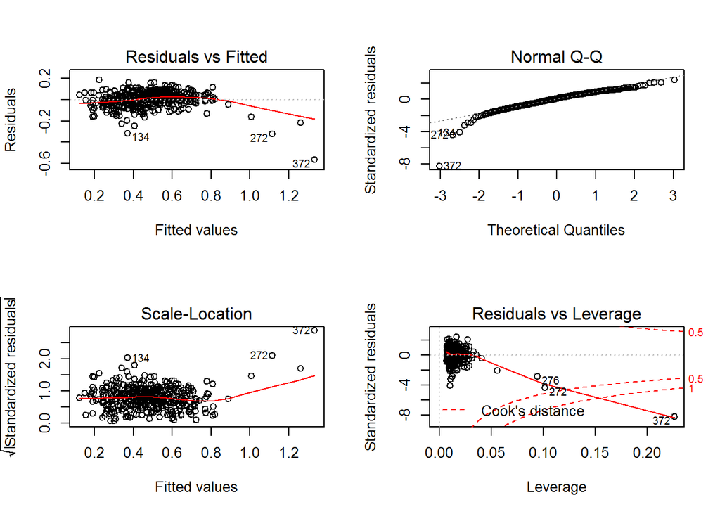

```r
model1 <- lm(islaidosVaisiams ~ butinosIslaidos + pajamos + rajonoId + atstumasIkiParduotuves, data = data2)
par(mfrow = c(2,2))
plot(model1)
```

Bene visuose grafikuose plika akimi galime pastebėti tikėtinas išskirtis [372, 272, 134].

```r
outlierTest(model1)
```

```
##      rstudent unadjusted p-value Bonferonni p
## 372 -9.036792         6.8125e-18   2.7931e-15
## 272 -4.505175         8.6997e-06   3.5669e-03
## 134 -4.176178         3.6360e-05   1.4908e-02
```

```r
which(is.na(data1))#atsižvelgiame į jau pašalintas NAN reikšmes, todėl išskirčių eilės numeris gali keistis
```

```
## [1]   57  154  424 1131 1342
```

```r
data <- data2[-c(131, 268, 367),]
attach(data)
```

**Kintamųjų apžvalga**

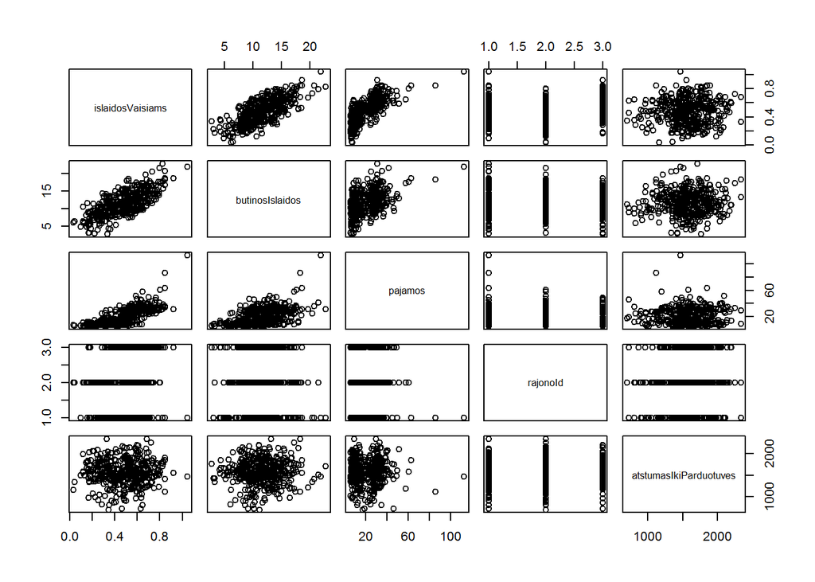

```r
plot(data)
```

Iš grafiko matome, kad tikėtinai yra priklausomybė tarp kintamųjų islaidosVaisiams ir butinosIslaidos, islaidosVaisiams ir pajamos, butinosIslaidos ir pajamos.

```r
cor(data$islaidosVaisiams, data$butinosIslaidos)
```

```
## [1] 0.729478
```

```r
cor(data$islaidosVaisiams, data$pajamos)
```

```
## [1] 0.7630099
```

```r
cor(data$pajamos, data$butinosIslaidos)
```

```
## [1] 0.4857474
```

Iš tikro, matome, kad dalinė koreliacija tarp pajamų ir būtinų išlaidų yra (tai mums sufleruoja apie multikolinearumo problemą). Taip pat matome, kad yra stipri koreliacija tarp kintamųjų islaidosVaisiams ir butinosIslaidos, islaidosVaisiams ir pajamos.

**Padalinsime duomenis į trainset ir testset.** [šaltinis](https://stat.ethz.ch/pipermail/r-help/2005-November/082516.html%5D)

```r
sub <- sample(nrow(data), floor(nrow(data) * 0.8))
trainSet <- data[sub, ]
testSet <- data[-sub, ]
```

**2.**

**Sudarome tiesinį modelį.**

```r
fit1 <- lm(islaidosVaisiams ~ butinosIslaidos + pajamos + rajonoId + atstumasIkiParduotuves, data = trainSet)
summary(fit1)
```

```
##
## Call:
## lm(formula = islaidosVaisiams ~ butinosIslaidos + pajamos + rajonoId +
##     atstumasIkiParduotuves, data = trainSet)
##
## Residuals:
##      Min       1Q   Median       3Q      Max
## -0.34638 -0.03864  0.00470  0.04299  0.17552
##
## Coefficients:
##                          Estimate Std. Error t value Pr(>|t|)
## (Intercept)             1.405e-02  2.493e-02   0.564    0.573
## butinosIslaidos         2.416e-02  1.306e-03  18.500  < 2e-16 ***
## pajamos                 7.307e-03  3.304e-04  22.113  < 2e-16 ***
## rajonoId2              -4.651e-02  9.051e-03  -5.139 4.83e-07 ***
## rajonoId3               9.494e-02  9.652e-03   9.837  < 2e-16 ***
## atstumasIkiParduotuves  1.372e-05  1.281e-05   1.071    0.285
## ---
## Signif. codes:  0 '***' 0.001 '**' 0.01 '*' 0.05 '.' 0.1 ' ' 1
##
## Residual standard error: 0.06818 on 319 degrees of freedom
## Multiple R-squared:  0.8505, Adjusted R-squared:  0.8482
## F-statistic: 363.1 on 5 and 319 DF,  p-value: < 2.2e-16
```

**Pašaliname nereikšmingus kintamuosius**

Matome, kad kintamasis atstumasIkiParduotuves yra nereikšmingas. Pašalinkime jį.

```r
modelis2 <- lm(islaidosVaisiams ~ butinosIslaidos + pajamos + rajonoId, data = trainSet)
summary(modelis2)
```

```
##
## Call:
## lm(formula = islaidosVaisiams ~ butinosIslaidos + pajamos + rajonoId,
##     data = trainSet)
##
## Residuals:
##      Min       1Q   Median       3Q      Max
## -0.34812 -0.03799  0.00687  0.04547  0.17559
##
## Coefficients:
##                   Estimate Std. Error t value Pr(>|t|)
## (Intercept)      0.0351535  0.0152687   2.302    0.022 *
## butinosIslaidos  0.0241787  0.0013060  18.514  < 2e-16 ***
## pajamos          0.0073096  0.0003305  22.116  < 2e-16 ***
## rajonoId2       -0.0461551  0.0090469  -5.102 5.78e-07 ***
## rajonoId3        0.0952489  0.0096500   9.870  < 2e-16 ***
## ---
## Signif. codes:  0 '***' 0.001 '**' 0.01 '*' 0.05 '.' 0.1 ' ' 1
##
## Residual standard error: 0.06819 on 320 degrees of freedom
## Multiple R-squared:   0.85,  Adjusted R-squared:  0.8481
## F-statistic: 453.3 on 4 and 320 DF,  p-value: < 2.2e-16
```

Palyginkime modelius pagal AKAIKE kriterijų.

```r
AIC(fit1)
```

```
## [1] -815.4284
```

```r
AIC(modelis2)
```

```
## [1] -816.2623
```

Pagal AKAIKE, matome, kad paskutinis sudarytas modelis yra geresnis.

**Patikriname dėl multikolinearumo.** Tinkama priemone patikrinti, ar modelyje egzistuoja multikolinearumo problema, yra Variance Inflation Factor (VIF). Jei kuris nors VIF koeficientas > 10, tai yra neblogas argumentas teigti, kad modelyje yra multikolinearumas.

```r
vif(modelis2)
```

```
##                     GVIF Df GVIF^(1/(2*Df))
## butinosIslaidos 1.343419  1        1.159060
## pajamos         1.357001  1        1.164904
## rajonoId        1.020083  2        1.004983
```

Jei multikolinearumas egzistuotų, reikštų, kad kai kurie kintamieji stipriai veikia vienas kitą, todėl gali būti sunku įvertinti jų atskirą įtaką kainai.

**Patikriname dėl heteroskedastiškumo.**

```r
ncvTest(modelis2)
```

```
## Non-constant Variance Score Test
## Variance formula: ~ fitted.values
## Chisquare = 40.08655    Df = 1     p = 2.429564e-10
```

ncvTest funkcija atlieka testą su nuline hipoteze, kad modelis homoskedastiškas ir alternatyva, kad modelis heteroskedastiškas.

p-value < 0.05, todėl atmetame H0, tai reiškia modelis yra heteroskedastiškas. Kintamųjų koeficientų įvertinių dispersijos yra paslinktos, todėl ir kintamųjų p-value gali būti neteisingos. Vadinasi, negalime įvertinti kintamųjų tinkamai. Todėl pasinaudosime White’o korekcija, kuri pataisys paklaidas ir p-value.

```r
library(lmtest)
coeftest(modelis2, vcov= hccm(modelis2))
```

```
##
## t test of coefficients:
##
##                   Estimate Std. Error t value  Pr(>|t|)
## (Intercept)      0.0351535  0.0180930  1.9429    0.0529 .
## butinosIslaidos  0.0241787  0.0012544 19.2748 < 2.2e-16 ***
## pajamos          0.0073096  0.0008177  8.9392 < 2.2e-16 ***
## rajonoId2       -0.0461551  0.0094144 -4.9026 1.507e-06 ***
## rajonoId3        0.0952489  0.0091859 10.3690 < 2.2e-16 ***
## ---
## Signif. codes:  0 '***' 0.001 '**' 0.01 '*' 0.05 '.' 0.1 ' ' 1
```

**Patikriname paklaidų normalumą.**

```r
res <- as.vector(modelis2$residuals)
shapiro.test(res)
```

```
##
##  Shapiro-Wilk normality test
##
## data:  res
## W = 0.96071, p-value = 1.144e-07
```

shapiro.test funkcija atmeta nulinę hipotezę, kad modelio liekanos išsidėsčiusios pagal normalųjį skirstinį (p-value < 0.05). Tai reiškia, kad gali būti, jog mūsų modelyje nėra tiesinės priklausomybės Y ir X’ų. Tačiau ši savybė nebūtinai visada turi būti [tenkinama](http://stats.stackexchange.com/questions/100214/assumptions-of-linear-models-and-what-to-do-if-the-residuals-are-not-normally-di).

**3.**

**Išbrėžiame 2 sklaidos diagramas, kaip reikalauja sąlyga**

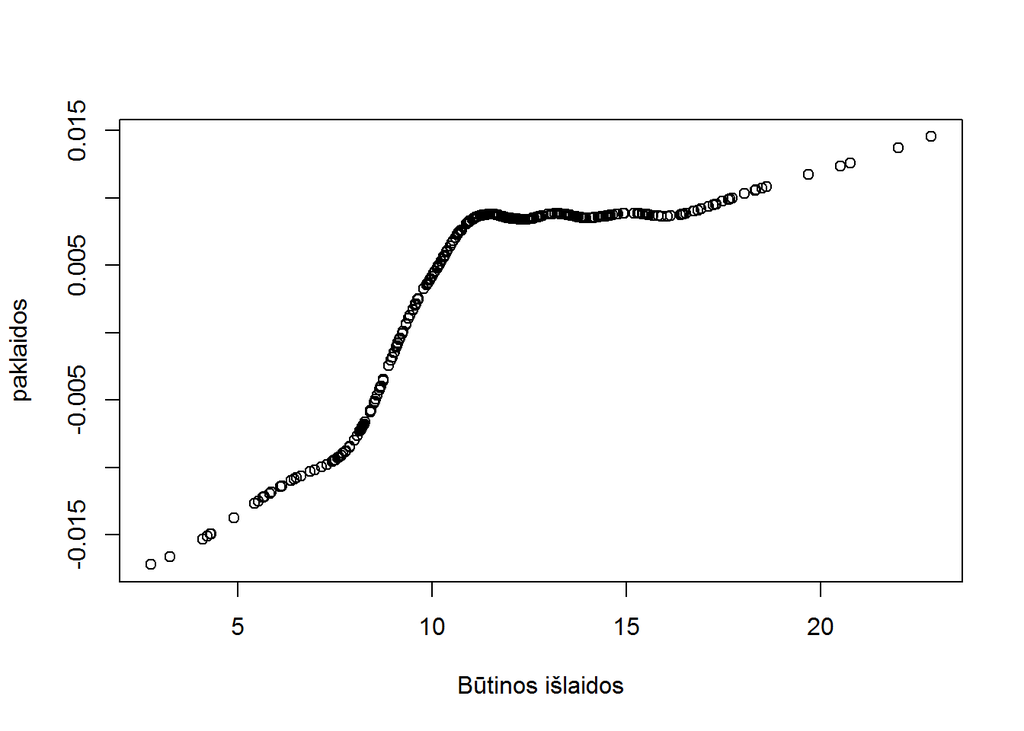

```r
par(mfrow = c(1,1))
plot(lowess(trainSet$butinosIslaidos, modelis2$res), ylab = "paklaidos", xlab = "Būtinos išlaidos")
```

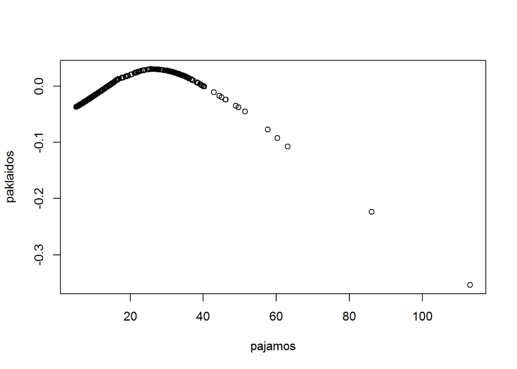

```r
plot(lowess(trainSet$pajamos, modelis2$res), ylab = "paklaidos", xlab = "pajamos")
```

Iš grafikų matome, kad ko gero nėra tiesinės priklausomybės, todėl pabandykime logaritmuoti kintamuosius.

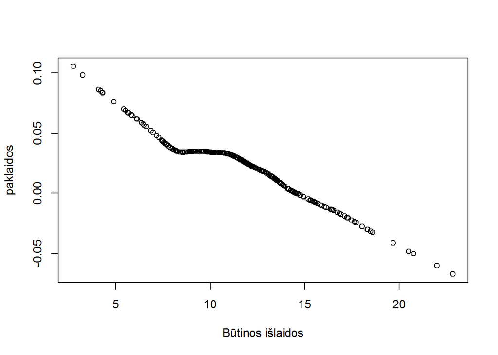

```r
fit2 <- lm(log(islaidosVaisiams) ~ log(butinosIslaidos) + log(pajamos) + rajonoId, data = trainSet)
plot(lowess(trainSet$butinosIslaidos, fit2$res), ylab = "paklaidos", xlab = "Būtinos išlaidos")
```

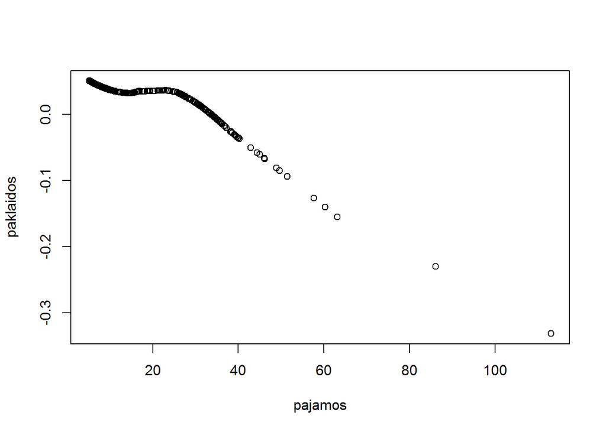

```r
plot(lowess(trainSet$pajamos, fit2$res), ylab = "paklaidos", xlab = "pajamos")
```

**4.**

**Suskaičiuosime modelių MSE**

```r
fit11 <- lm(islaidosVaisiams ~ butinosIslaidos + pajamos + rajonoId + atstumasIkiParduotuves, data = testSet)
fit22 <- lm(log(islaidosVaisiams) ~ log(butinosIslaidos) + log(pajamos) + rajonoId, data = testSet)
mse1 <- sum((fit1$res)^2)/length(fit1$res)
mse2 <- sum((fit2$res)^2)/length(fit2$res)
mse3 <- sum((fit11$res)^2)/length(fit11$res)
mse4 <- sum((fit22$res)^2)/length(fit22$res)
```

**Rezultatų lentelė**

```r
Modeliai <- c("fit1", "fit2")
MSEtrainSet <- c(mse1, mse2)
MSEtestSet <- c(mse3, mse4)
data.frame(Modeliai, MSEtrainSet, MSEtestSet)
```

```
##   Modeliai MSEtrainSet  MSEtestSet
## 1     fit1 0.004562136 0.002638888
## 2     fit2 0.048713606 0.024202345
```

Pagal MSE, fit1 modelis geresnis.

```r
fitMain <- lm(islaidosVaisiams ~ butinosIslaidos + pajamos + rajonoId + atstumasIkiParduotuves, data = trainSet)
```

islaidosVaisiams ~ butinosIslaidos + pajamos + rajonoId + atstumasIkiParduotuves

```r
fitMain1 <- lm(islaidosVaisiams ~ butinosIslaidos + pajamos + rajonoId + atstumasIkiParduotuves, data = testSet)
f1 <- forecast(fitMain, trainSet)
```

# 3 užduotis

**Įsirašome duomenis**

```r
library(dynlm)
data <- M1Germany
```

**Randame vidutinį santykinį augimo tempą**

vsat = (data$logprice[N]/data$logprice[1])^1/N - 1

**Sudarome modelį**

```r
mod1 <- dynlm(data$logprice~L(data$loggnp, 1) + d(L(data$loggnp, 2)))
summary(mod1)
```

```
##
## Time series regression with "zooreg" data:
## Start = 1960 Q4, End = 1996 Q1
##
## Call:
## dynlm(formula = data$logprice ~ L(data$loggnp, 1) + d(L(data$loggnp,
##     2)))
##
## Residuals:
##      Min       1Q   Median       3Q      Max
## -0.18535 -0.06962 -0.01279  0.06643  0.26184
##
## Coefficients:
##                       Estimate Std. Error t value Pr(>|t|)
## (Intercept)          -11.06151    0.34114  -32.42   <2e-16 ***
## L(data$loggnp, 1)      1.71053    0.03837   44.58   <2e-16 ***
## d(L(data$loggnp, 2))  -0.26488    0.15577   -1.70   0.0913 .
## ---
## Signif. codes:  0 '***' 0.001 '**' 0.01 '*' 0.05 '.' 0.1 ' ' 1
##
## Residual standard error: 0.1055 on 139 degrees of freedom
## Multiple R-squared:  0.9349, Adjusted R-squared:  0.9339
## F-statistic: 997.7 on 2 and 139 DF,  p-value: < 2.2e-16
```

**Gauname jo liekanas**

```r
liek <- ts(mod1$residuals,start=c(1960,1), frequency = 4)
```

**Šaliname sezoniškumą:**

```r
stl <- stl(liek, s.window="periodic")
ser <- liek - stl$time.series[,"seasonal"]
```

**Tikriname stacionarumą**

Išbrėžiame liekanų grafiką

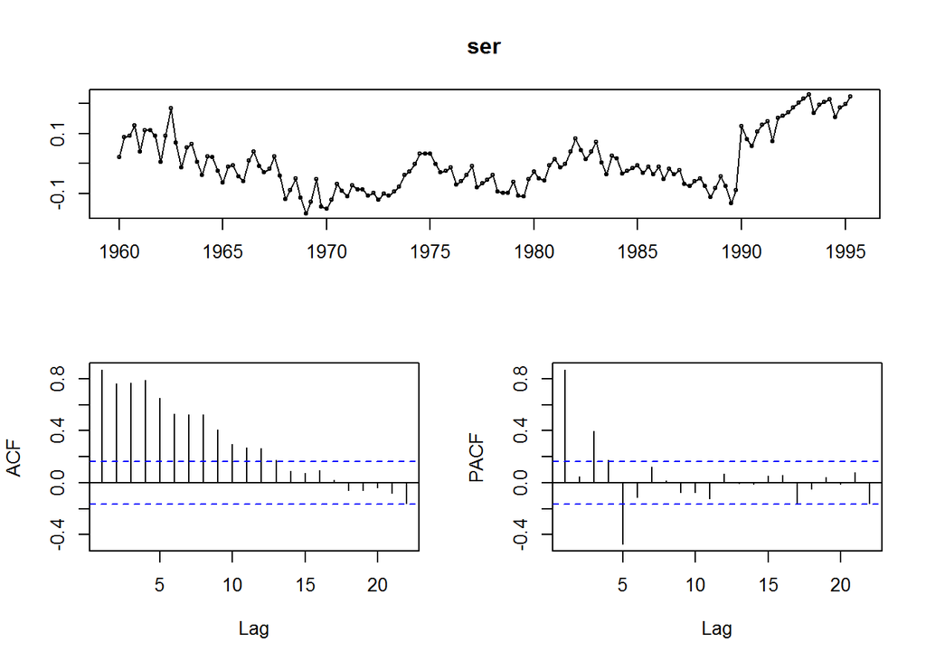

```r
tsdisplay(ser)
```

Laiko eilutė žiūrint į grafikus galimai nėra stacionari. Įsitikinkime:

```r
n <- ndiffs(ser)
n#diferencijavimo eilė
```

```
## [1] 1
```

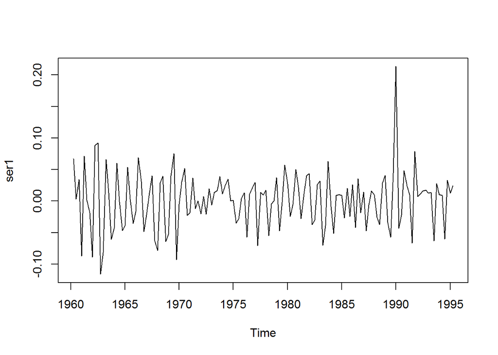

```r
ser1 <- diff(ser, diff = n)
plot(ser1)
```

Liekanas reikėjo diferencijuoti vieną kartą. Dabar jos tapo panašesnės į stacionarias. Patikrinkime su KPSS testu.

```r
kpss.test(ser1)
```

```
##
##  KPSS Test for Level Stationarity
##
## data:  ser1
## KPSS Level = 0.16049, Truncation lag parameter = 2, p-value = 0.1
```

p-value > 0.05, priimam H0, vadinasi galime teigti, kad laiko eilutė yra stacionari.

Nemanau, kad reiktų Box-Cox transformacijos, nes svyravimai nėra pvz.: tolygiai didėjantys, todėl manau, kad Box-Cox neatliktų savo funkcijos - suvienodinti svyravimus.

**Panaudojama ets funkcija randame siūlomą eksponentinio glodinimo modelį**

```r
mod1<-ets(ser)
mod1[13]
```

```
## $method
## [1] "ETS(A,N,A)"
```

A - adityvios paklaidos N - nėra trendo A - adityvūs sezoniniai svyravimai

**Randame kitas dvi alternatyvas**

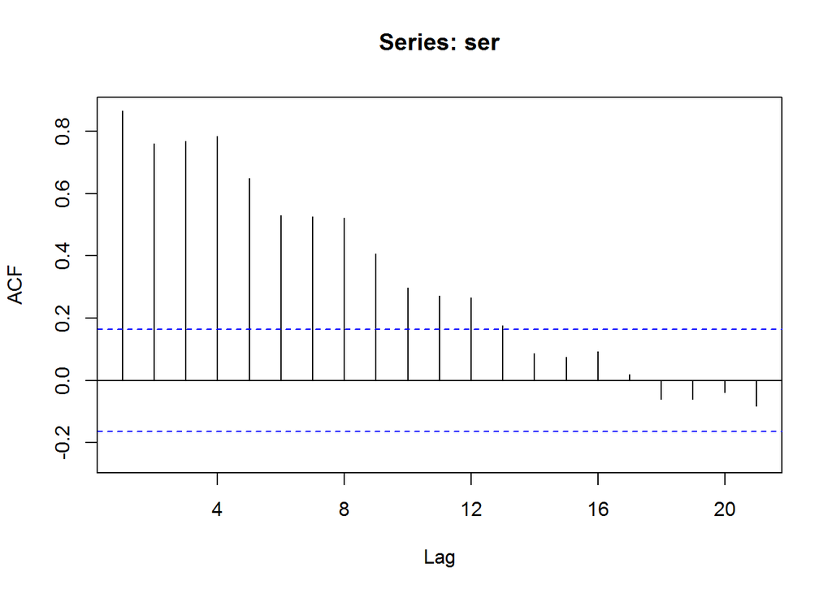

```r
Acf(ser)
```

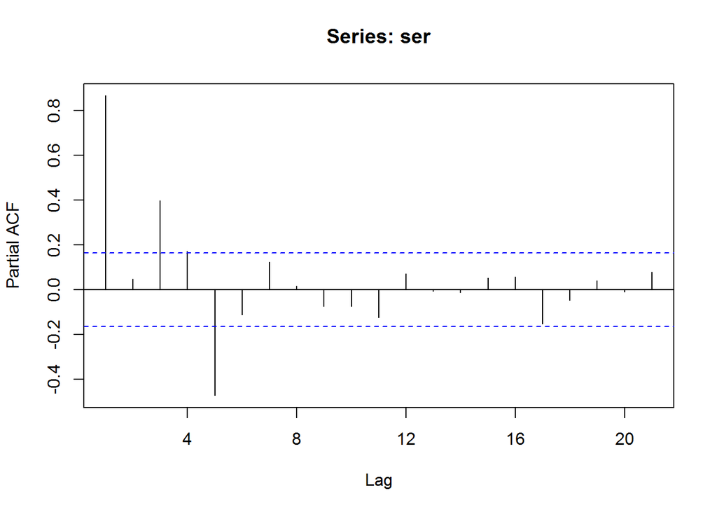

```r
Pacf(ser)
```

```r
fitas1 <- Arima(ser, order = c(5,1,0))
fitas2 <- Arima(ser, order = c(0,1,13))
```

```r
accuracy(mod1)[2]
```

```
## [1] 0.03262734
```

```r
accuracy(fitas1)[2]
```

```
## [1] 0.03190274
```

```r
accuracy(fitas2)[2]
```

```
## [1] 0.03071396
```

Pagal RMSE geriausias modelis - ARIMA(0,1,13).

```r
mod2 <- Arima(ser, order = c(0,1,13))
```

Nuo mod1 šis modelis skiriasi tuom, kad šiam modeliui sukurti naudojama ARIMA, o mod1 naudojome ETS.

**Pritaikome auto.arima**

```r
auto.arima(ser)
```

```
## Series: ser
## ARIMA(2,1,2)(1,0,2)[4]
##
## Coefficients:
##          ar1      ar2      ma1     ma2     sar1    sma1    sma2
##       0.0523  -0.9751  -0.1727  0.8969  -0.4036  0.7729  0.2086
## s.e.  0.0245   0.0263   0.0491  0.0724   0.7823  0.7634  0.2598
##
## sigma^2 estimated as 0.0009822:  log likelihood=286.64
## AIC=-557.27   AICc=-556.18   BIC=-533.68
```

```r
mod3 <- auto.arima(ser)
```

ARIMA(p,d,q)(P,D,Q)[m] p,d,q - nonseasonal part of the model P,D,Q - seasonal part of the model AR: p, P = order of the autoregressive part I: d, D = degree of first differencing involved MA: q, Q = order of the moving average part m - number of periods per season.

Pasiūlyta integruotumo eilė sutampa su 1.c atsakyme pasiūlyta eile.

**Sukurkime dar 2 modelius**

```r
fit1 <- Arima(ser, order=c(5,1,0), seasonal=c(1,0,1))
fit2 <- Arima(ser, order=c(0,1,13), seasonal=c(1,0,2))
```

**Palyginkime visus 3 modelius pagal RMSE**

```r
accuracy(mod3)[2]
```

```
## [1] 0.03122935
```

```r
accuracy(fit1)[2]
```

```
## [1] 0.03141573
```

```r
accuracy(fit2)[2]
```

```
## [1] 0.02910835
```

Pagal RMSE geriausias modelis - ARIMA(0,1,13)(1,0,2)[4].

```r
mod4 <- Arima(ser, order=c(0,1,13), seasonal=c(1,0,2))
```

**Patikriname visų 4 modelių liekanas**

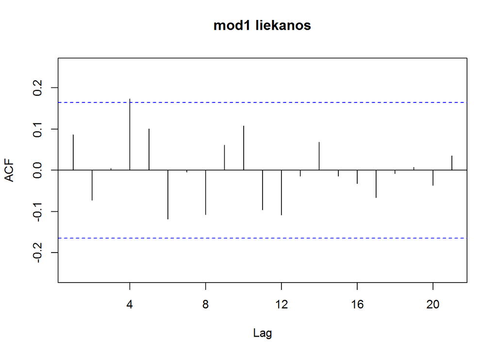

```r
Acf(mod1$res, main = "mod1 liekanos")
```

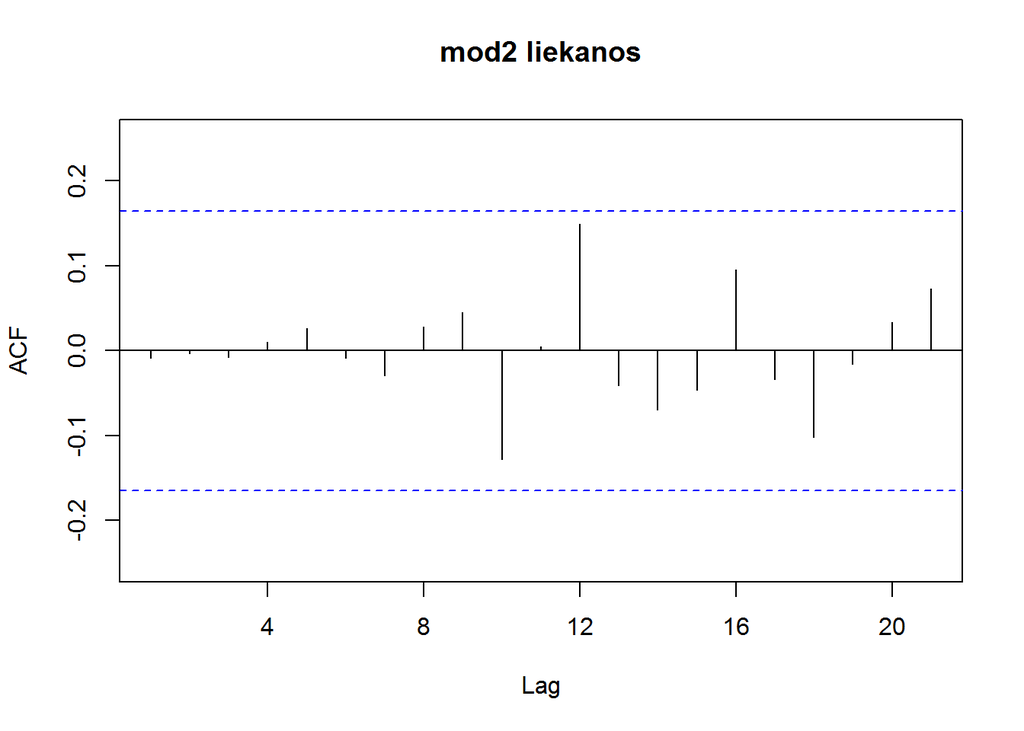

```r
Acf(mod2$res, main = "mod2 liekanos")
```

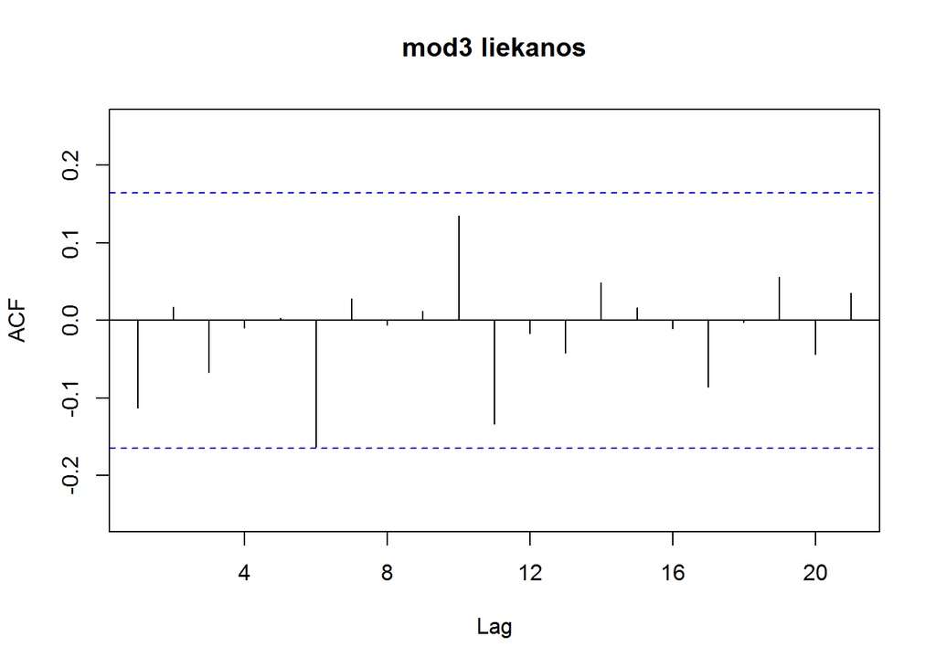

```r
Acf(mod3$res, main = "mod3 liekanos")
```

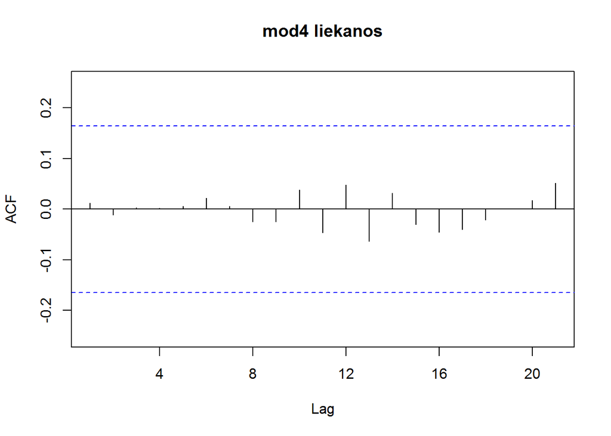

```r
Acf(mod4$res, main = "mod4 liekanos")
```

Visų 4 modelių liekanos panašios į baltasis triukšmą. Patikrinkime su Ljung-Box testu, kur H0 hipoteze, kad duomenų liekanos yra baltasis triukšmas ir alternatyva, kad nėra.

```r
Box.test(mod1$res, type="Lj")
```

```
##
##  Box-Ljung test
##
## data:  mod1$res
## X-squared = 1.0736, df = 1, p-value = 0.3001
```

```r
Box.test(mod2$res, type="Lj")
```

```
##
##  Box-Ljung test
##
## data:  mod2$res
## X-squared = 0.011224, df = 1, p-value = 0.9156
```

```r
Box.test(mod3$res, type="Lj")
```

```
##
##  Box-Ljung test
##
## data:  mod3$res
## X-squared = 1.8486, df = 1, p-value = 0.1739
```

```r
Box.test(mod4$res, type="Lj")
```

```
##
##  Box-Ljung test
##
## data:  mod4$res
## X-squared = 0.019182, df = 1, p-value = 0.8898
```

Visi p-value > 0.05, visuose 4 atvejuose priimam H0, vadinasi visų 4 modelių liekanos yra baltasis triukšmas.

**ser padaliname į trainSet ir testSet**

```r
trainSet <- window(ser, end = c(1987,4))
testSet <- window(ser, start = c(1988, 1))
```

**Įvertiname visus 4 modelius naudodami trainSet**

```r
mod11 <- ets(trainSet)
mod22 <- Arima(trainSet, order = c(0,1,13))
mod33 <- auto.arima(trainSet)
mod44 <- Arima(trainSet, order=c(0,1,13), seasonal=c(1,0,2))
```

**Išbrėžiame prognozes** Melyna linija - modelio prognozė; žalia linija - tikrosios reikšmės.

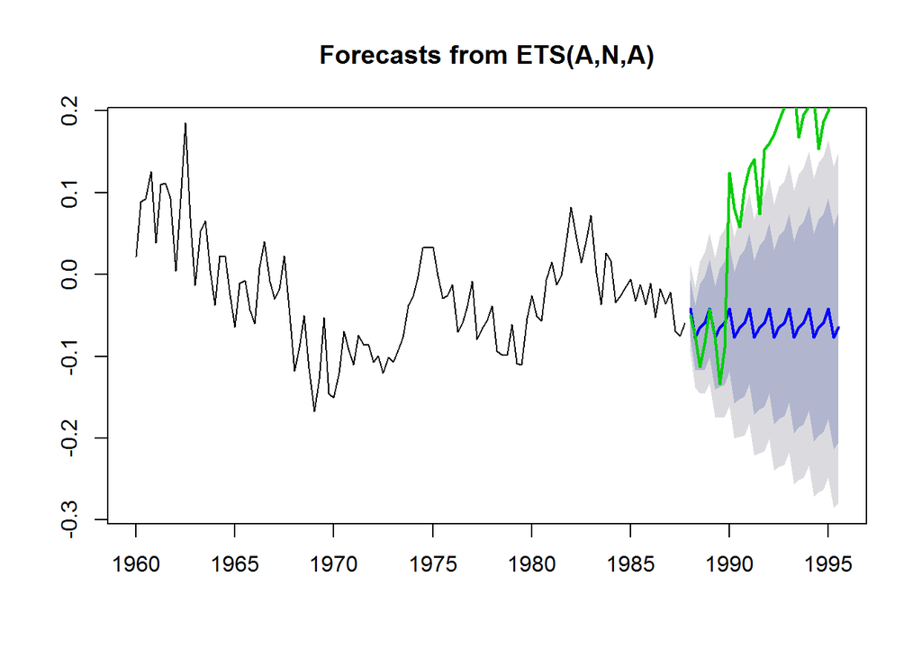

```r
plot(forecast(mod11, h=31))
lines(testSet, lwd=2, col=3)
```

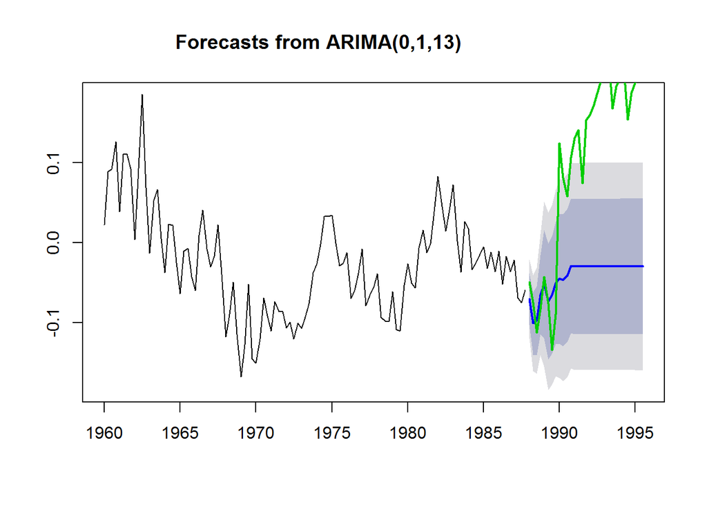

```r
plot(forecast(mod22, h=31))
lines(testSet, lwd=2, col=3)
```

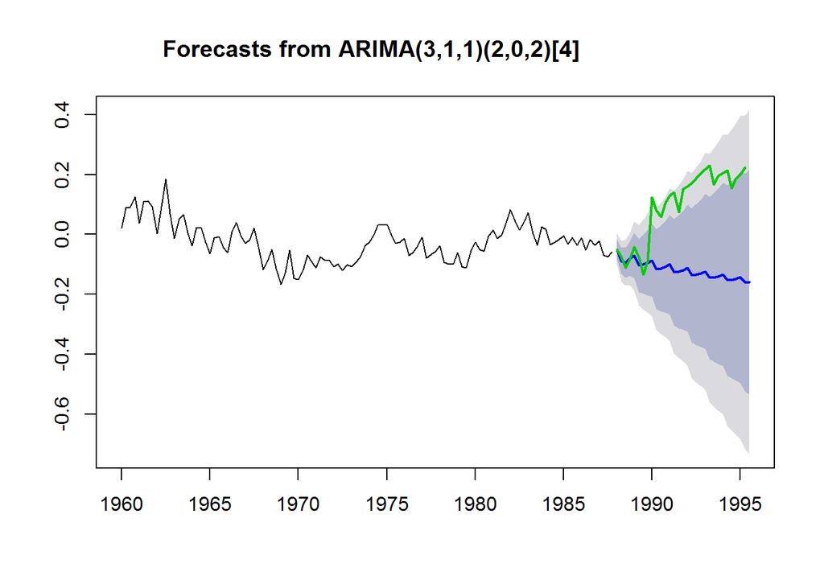

```r
plot(forecast(mod33, h=31))
lines(testSet, lwd=2, col=3)
```

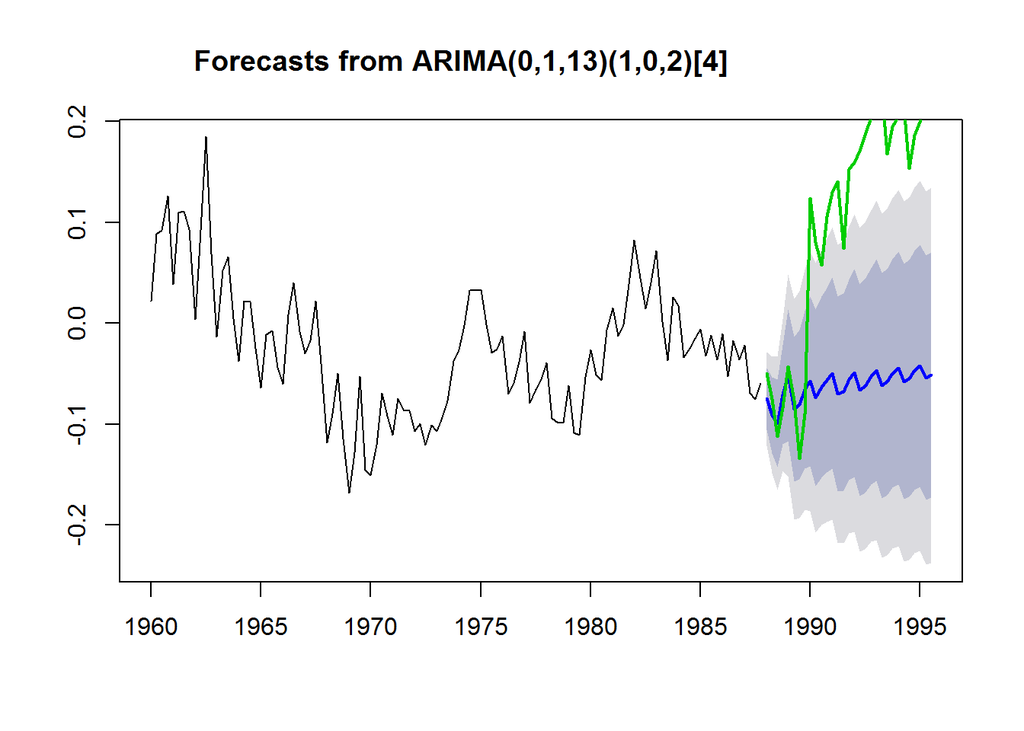

```r
plot(forecast(mod44, h=31))
lines(testSet, lwd=2, col=3)
```

Mano nuomone tiksliausiai atrodo paskutiniojo modelio (ARIMA(0,1,13)(1,0,2)[4]) prognozė, jo reikšmės kyla, atsižvelgta į sezoniškumą.

**Patikrinsime visų modelių tikslumą su funkcija accuracy.**

```r
f1 <- forecast(mod11, h=31)
f2 <- forecast(mod22, h=31)
f3 <- forecast(mod33, h=31)
f4 <- forecast(mod44, h=31)
accuracy(f1, testSet)
```

```
##                        ME       RMSE       MAE       MPE     MAPE
## Training set -0.001703521 0.02691784 0.0214670 -22.28572 133.8289
## Test set      0.157761360 0.19677135 0.1698687 110.80192 111.0159
##                   MASE      ACF1 Theil's U
## Training set 0.6313683 0.1124321        NA
## Test set     4.9960263 0.8357813  2.361696
```

```r
accuracy(f2, testSet)
```

```
##                        ME       RMSE        MAE       MPE      MAPE
## Training set -0.003132425 0.02477258 0.01949126  5.444016 117.55418
## Test set      0.139904181 0.17221492 0.14943968 91.780712  98.28162
##                   MASE       ACF1 Theil's U
## Training set 0.5732596 -0.0125794        NA
## Test set     4.3951862  0.8268327  2.059199
```

```r
accuracy(f3, testSet)
```

```
##                         ME       RMSE        MAE        MPE     MAPE
## Training set -0.0004927892 0.02671344 0.02031384   4.164778 137.3045
## Test set      0.2151666694 0.25627530 0.21877759 135.447907 143.9363
##                   MASE       ACF1 Theil's U
## Training set 0.5974524 0.01912777        NA
## Test set     6.4344908 0.86780164  3.058667
```

```r
accuracy(f4, testSet)
```

```
##                        ME       RMSE        MAE        MPE     MAPE
## Training set -0.001780491 0.02313265 0.01840442  -3.313681 117.6964
## Test set      0.159141967 0.19197245 0.16603748 103.252757 110.0707
##                   MASE        ACF1 Theil's U
## Training set 0.5412944 0.006386653        NA
## Test set     4.8833458 0.844732399  2.321098
```

```r
modMain <- Arima(trainSet, order=c(0,1,13), seasonal=c(1,0,2))
```